# Diamond_Analysis

Ala Albin Saleh

10/01/2021

## Results

### Dataset Description:

The diamonds dataset is build-in ggplot2 and it contains 10 attributes and entries of 53940 diamonds.

| attribute | Description |
| --- | --- |
| price | Price in US dollars |
| carat | Weight of the diamond |
| cut | Quality of the cut |
| color | Diamond’s colour |
| clarity | Measurement of how clear the diamond |
| x | Length of diamonds in mm |
| y | Width of diamonds in mm |
| z | Depth of diamonds in mm |
| depth | Total depth percentage |
| table | Width of top of diamond relative to widest point |

**Preview of the diamond dataset (top 100 rows)**

|  | carat | cut | color | clarity | depth | table | price | x | y | z |
| --- | --- | --- | --- | --- | --- | --- | --- | --- | --- | --- |
| 1 | 0.23 | Ideal | E | SI2 | 61.5 | 55 | 326 | 3.95 | 3.98 | 2.43 |
| 2 | 0.21 | Premium | E | SI1 | 59.8 | 61 | 326 | 3.89 | 3.84 | 2.31 |
| 3 | 0.23 | Good | E | VS1 | 56.9 | 65 | 327 | 4.05 | 4.07 | 2.31 |
| 4 | 0.29 | Premium | I | VS2 | 62.4 | 58 | 334 | 4.2 | 4.23 | 2.63 |
| 5 | 0.31 | Good | J | SI2 | 63.3 | 58 | 335 | 4.34 | 4.35 | 2.75 |
| 6 | 0.24 | Very Good | J | VVS2 | 62.8 | 57 | 336 | 3.94 | 3.96 | 2.48 |
| 7 | 0.24 | Very Good | I | VVS1 | 62.3 | 57 | 336 | 3.95 | 3.98 | 2.47 |
| 8 | 0.26 | Very Good | H | SI1 | 61.9 | 55 | 337 | 4.07 | 4.11 | 2.53 |
| 9 | 0.22 | Fair | E | VS2 | 65.1 | 61 | 337 | 3.87 | 3.78 | 2.49 |
| 10 | 0.23 | Very Good | H | VS1 | 59.4 | 61 | 338 | 4 | 4.05 | 2.39 |

[output cut: 90 more lines]

### Descriptive Statistics:

- **The mean:** The sum of all values divided by the total numbers of values
- **The median:** The middle value in set of values
- **Range:**: The difference between the maximum value and minimum value
- **IQR:** The difference between the tird quantile (Q3) and first quantile (Q1).
- **Variance:** Thhe average of the squared differences between each indiviual value and the mean
- **Standard Deviation:** The square root of the variance

```
## # A tibble: 8 × 7
##   clarity  Mean Median Range   IQR  Variance Standard_Deviation
##   <ord>   <dbl>  <dbl> <int> <dbl>     <dbl>              <dbl>
## 1 I1      3924.   3344 18186 3081   7878004.              2807.
## 2 SI2     5063.   4072 18478 3513. 18151507.              4260.
## 3 SI1     3996.   2822 18492 4161  14436078.              3799.
## 4 VS2     3925.   2054 18489 5124. 16340212.              4042.
## 5 VS1     3839.   2005 18468 5147  16094122.              4012.
## 6 VVS2    3284.   1311 18432 2844  14604990.              3822.
## 7 VVS1    2523.   1093 18441 1563  11121150.              3335.
## 8 IF      2865.   1080 18437 1494. 15368348.              3920.
```

**NOTE:** the above statistics are base on the clarity of a diamond.

### Inferential Statistics:

**- T-Test**

let the Null hypothesis be that the carat has no effect on the price. *H0: carat and price are independent*

```r
ttest <- t.test(diamonds$carat, diamonds$price)
ttest
```

```
##
##  Welch Two Sample t-test
##
## data:  diamonds$carat and diamonds$price
## t = -228.91, df = 53939, p-value < 2.2e-16
## alternative hypothesis: true difference in means is not equal to 0
## 95 percent confidence interval:
##  -3965.670 -3898.334
## sample estimates:
##    mean of x    mean of y
##    0.7979397 3932.7997219
```

Decision:

```
## [1] "Rejecting the Null hypothesis"
```

**- Linear regression:**

```r
  LinearModel <- lm(price ~ clarity, data= diamonds)
```

```
##
## Call:
## lm(formula = price ~ clarity, data = diamonds)
##
## Coefficients:
## (Intercept)    clarity.L    clarity.Q    clarity.C    clarity^4    clarity^5
##     3677.42     -1723.35      -428.36       647.87      -123.13       804.81
##   clarity^6    clarity^7
##     -273.65        81.19
```

**-ANOVA:**

```r
anova <- aov(price ~ clarity, data = diamonds)
```

```
## Call:
##    aov(formula = price ~ clarity, data = diamonds)
##
## Terms:
##                      clarity    Residuals
## Sum of Squares   23307802882 835165332636
## Deg. of Freedom            7        53932
##
## Residual standard error: 3935.165
## Estimated effects may be unbalanced
```

### Data Visualization:

- This Scatter plot illustrate the relationship between carat and price

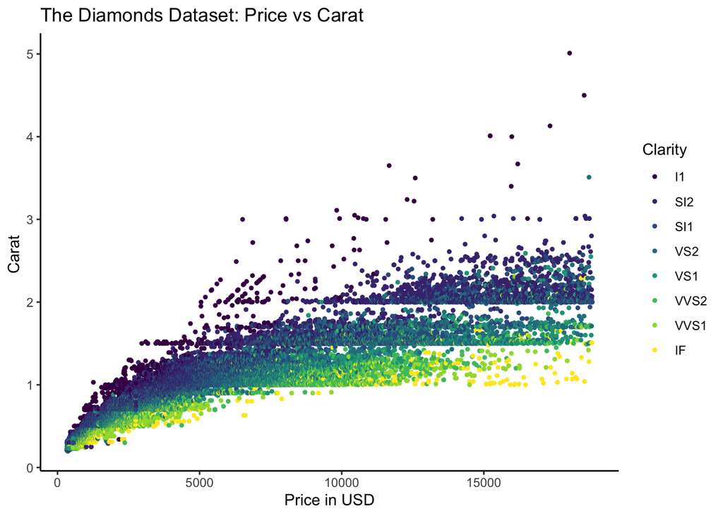

- This Scatter plot illustrate the relationship between carat and price with smoothing trend {lm}

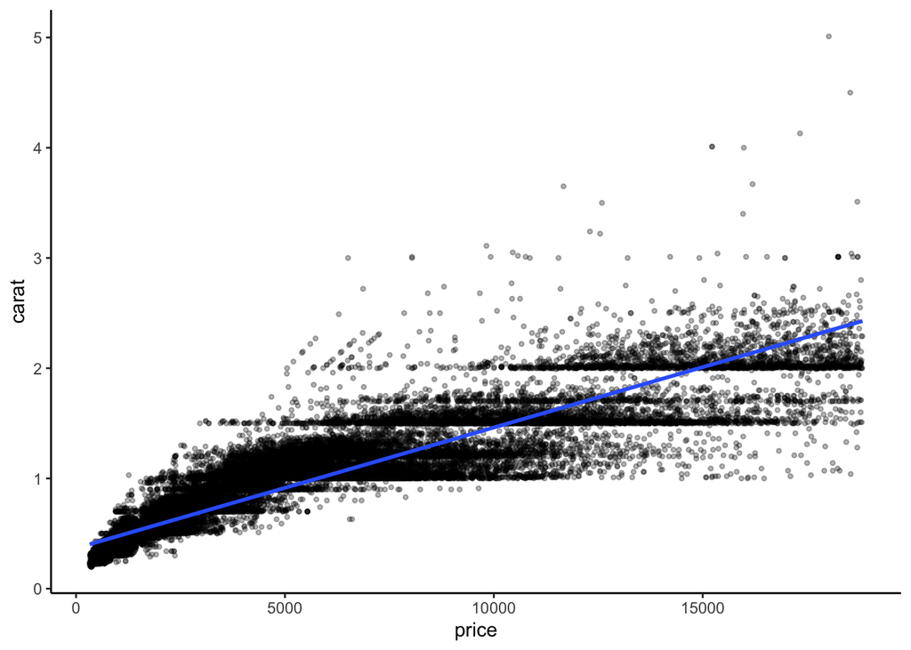